# Risk Factor Analysis

## Outcome Variable

**Outcome Variable:** y_rate_haz

## Predictor Variables

**Intervention Variable:** predfeed3

**Adjustment Set:**

unadjusted

## Stratifying Variables

The analysis was stratified on these variable(s):

- agecat
- studyid
- country

## Data Summary

| agecat | studyid | country | predfeed3 | n_cell | n |
| --- | --- | --- | --- | --- | --- |
| 0-3 months | EE | PAKISTAN | 1 | 31 | 31 |
| 0-3 months | EE | PAKISTAN | 0 | 0 | 31 |
| 0-3 months | GMS-Nepal | NEPAL | 1 | 378 | 456 |
| 0-3 months | GMS-Nepal | NEPAL | 0 | 78 | 456 |
| 0-3 months | JiVitA-3 | BANGLADESH | 1 | 10705 | 11852 |
| 0-3 months | JiVitA-3 | BANGLADESH | 0 | 1147 | 11852 |
| 0-3 months | JiVitA-4 | BANGLADESH | 1 | 111 | 121 |
| 0-3 months | JiVitA-4 | BANGLADESH | 0 | 10 | 121 |
| 0-3 months | MAL-ED | BANGLADESH | 1 | 193 | 237 |
| 0-3 months | MAL-ED | BANGLADESH | 0 | 44 | 237 |
| 0-3 months | MAL-ED | BRAZIL | 1 | 73 | 147 |
| 0-3 months | MAL-ED | BRAZIL | 0 | 74 | 147 |
| 0-3 months | MAL-ED | INDIA | 1 | 113 | 164 |
| 0-3 months | MAL-ED | INDIA | 0 | 51 | 164 |
| 0-3 months | MAL-ED | NEPAL | 1 | 81 | 153 |
| 0-3 months | MAL-ED | NEPAL | 0 | 72 | 153 |
| 0-3 months | MAL-ED | PERU | 1 | 168 | 262 |
| 0-3 months | MAL-ED | PERU | 0 | 94 | 262 |
| 0-3 months | MAL-ED | SOUTH AFRICA | 1 | 58 | 203 |
| 0-3 months | MAL-ED | SOUTH AFRICA | 0 | 145 | 203 |
| 0-3 months | MAL-ED | TANZANIA, UNITED REPUBLIC OF | 1 | 57 | 197 |
| 0-3 months | MAL-ED | TANZANIA, UNITED REPUBLIC OF | 0 | 140 | 197 |
| 3-6 months | EE | PAKISTAN | 1 | 31 | 31 |
| 3-6 months | EE | PAKISTAN | 0 | 0 | 31 |
| 3-6 months | GMS-Nepal | NEPAL | 1 | 350 | 420 |
| 3-6 months | GMS-Nepal | NEPAL | 0 | 70 | 420 |
| 3-6 months | JiVitA-3 | BANGLADESH | 1 | 6478 | 7103 |
| 3-6 months | JiVitA-3 | BANGLADESH | 0 | 625 | 7103 |
| 3-6 months | JiVitA-4 | BANGLADESH | 1 | 21 | 21 |
| 3-6 months | JiVitA-4 | BANGLADESH | 0 | 0 | 21 |

[output cut: 130 more lines]

The following strata were considered:

- agecat: 0-3 months, studyid: EE, country: PAKISTAN
- agecat: 0-3 months, studyid: GMS-Nepal, country: NEPAL
- agecat: 0-3 months, studyid: JiVitA-3, country: BANGLADESH
- agecat: 0-3 months, studyid: JiVitA-4, country: BANGLADESH
- agecat: 0-3 months, studyid: MAL-ED, country: BANGLADESH
- agecat: 0-3 months, studyid: MAL-ED, country: BRAZIL
- agecat: 0-3 months, studyid: MAL-ED, country: INDIA
- agecat: 0-3 months, studyid: MAL-ED, country: NEPAL
- agecat: 0-3 months, studyid: MAL-ED, country: PERU
- agecat: 0-3 months, studyid: MAL-ED, country: SOUTH AFRICA
- agecat: 0-3 months, studyid: MAL-ED, country: TANZANIA, UNITED REPUBLIC OF
- agecat: 12-15 months, studyid: EE, country: PAKISTAN
- agecat: 12-15 months, studyid: GMS-Nepal, country: NEPAL
- agecat: 12-15 months, studyid: JiVitA-4, country: BANGLADESH
- agecat: 12-15 months, studyid: MAL-ED, country: BANGLADESH
- agecat: 12-15 months, studyid: MAL-ED, country: BRAZIL
- agecat: 12-15 months, studyid: MAL-ED, country: INDIA
- agecat: 12-15 months, studyid: MAL-ED, country: NEPAL
- agecat: 12-15 months, studyid: MAL-ED, country: PERU
- agecat: 12-15 months, studyid: MAL-ED, country: SOUTH AFRICA
- agecat: 12-15 months, studyid: MAL-ED, country: TANZANIA, UNITED REPUBLIC OF
- agecat: 15-18 months, studyid: EE, country: PAKISTAN
- agecat: 15-18 months, studyid: GMS-Nepal, country: NEPAL
- agecat: 15-18 months, studyid: JiVitA-4, country: BANGLADESH
- agecat: 15-18 months, studyid: MAL-ED, country: BANGLADESH
- agecat: 15-18 months, studyid: MAL-ED, country: BRAZIL
- agecat: 15-18 months, studyid: MAL-ED, country: INDIA
- agecat: 15-18 months, studyid: MAL-ED, country: NEPAL
- agecat: 15-18 months, studyid: MAL-ED, country: PERU
- agecat: 15-18 months, studyid: MAL-ED, country: SOUTH AFRICA
- agecat: 15-18 months, studyid: MAL-ED, country: TANZANIA, UNITED REPUBLIC OF
- agecat: 18-21 months, studyid: EE, country: PAKISTAN
- agecat: 18-21 months, studyid: GMS-Nepal, country: NEPAL
- agecat: 18-21 months, studyid: MAL-ED, country: BANGLADESH
- agecat: 18-21 months, studyid: MAL-ED, country: BRAZIL
- agecat: 18-21 months, studyid: MAL-ED, country: INDIA
- agecat: 18-21 months, studyid: MAL-ED, country: NEPAL
- agecat: 18-21 months, studyid: MAL-ED, country: PERU
- agecat: 18-21 months, studyid: MAL-ED, country: SOUTH AFRICA
- agecat: 18-21 months, studyid: MAL-ED, country: TANZANIA, UNITED REPUBLIC OF
- agecat: 21-24 months, studyid: EE, country: PAKISTAN
- agecat: 21-24 months, studyid: GMS-Nepal, country: NEPAL
- agecat: 21-24 months, studyid: MAL-ED, country: BANGLADESH
- agecat: 21-24 months, studyid: MAL-ED, country: BRAZIL
- agecat: 21-24 months, studyid: MAL-ED, country: INDIA
- agecat: 21-24 months, studyid: MAL-ED, country: NEPAL
- agecat: 21-24 months, studyid: MAL-ED, country: PERU
- agecat: 21-24 months, studyid: MAL-ED, country: SOUTH AFRICA
- agecat: 21-24 months, studyid: MAL-ED, country: TANZANIA, UNITED REPUBLIC OF
- agecat: 3-6 months, studyid: EE, country: PAKISTAN
- agecat: 3-6 months, studyid: GMS-Nepal, country: NEPAL
- agecat: 3-6 months, studyid: JiVitA-3, country: BANGLADESH
- agecat: 3-6 months, studyid: JiVitA-4, country: BANGLADESH
- agecat: 3-6 months, studyid: MAL-ED, country: BANGLADESH
- agecat: 3-6 months, studyid: MAL-ED, country: BRAZIL
- agecat: 3-6 months, studyid: MAL-ED, country: INDIA
- agecat: 3-6 months, studyid: MAL-ED, country: NEPAL
- agecat: 3-6 months, studyid: MAL-ED, country: PERU
- agecat: 3-6 months, studyid: MAL-ED, country: SOUTH AFRICA
- agecat: 3-6 months, studyid: MAL-ED, country: TANZANIA, UNITED REPUBLIC OF
- agecat: 6-9 months, studyid: EE, country: PAKISTAN
- agecat: 6-9 months, studyid: GMS-Nepal, country: NEPAL
- agecat: 6-9 months, studyid: JiVitA-4, country: BANGLADESH
- agecat: 6-9 months, studyid: MAL-ED, country: BANGLADESH
- agecat: 6-9 months, studyid: MAL-ED, country: BRAZIL
- agecat: 6-9 months, studyid: MAL-ED, country: INDIA
- agecat: 6-9 months, studyid: MAL-ED, country: NEPAL
- agecat: 6-9 months, studyid: MAL-ED, country: PERU
- agecat: 6-9 months, studyid: MAL-ED, country: SOUTH AFRICA
- agecat: 6-9 months, studyid: MAL-ED, country: TANZANIA, UNITED REPUBLIC OF
- agecat: 9-12 months, studyid: EE, country: PAKISTAN
- agecat: 9-12 months, studyid: GMS-Nepal, country: NEPAL
- agecat: 9-12 months, studyid: JiVitA-4, country: BANGLADESH
- agecat: 9-12 months, studyid: MAL-ED, country: BANGLADESH
- agecat: 9-12 months, studyid: MAL-ED, country: BRAZIL
- agecat: 9-12 months, studyid: MAL-ED, country: INDIA
- agecat: 9-12 months, studyid: MAL-ED, country: NEPAL
- agecat: 9-12 months, studyid: MAL-ED, country: PERU
- agecat: 9-12 months, studyid: MAL-ED, country: SOUTH AFRICA
- agecat: 9-12 months, studyid: MAL-ED, country: TANZANIA, UNITED REPUBLIC OF

### Dropped Strata

Some strata were dropped due to rare outcomes:

- agecat: 0-3 months, studyid: EE, country: PAKISTAN
- agecat: 3-6 months, studyid: EE, country: PAKISTAN
- agecat: 3-6 months, studyid: JiVitA-4, country: BANGLADESH
- agecat: 6-9 months, studyid: EE, country: PAKISTAN
- agecat: 6-9 months, studyid: JiVitA-4, country: BANGLADESH
- agecat: 9-12 months, studyid: EE, country: PAKISTAN
- agecat: 12-15 months, studyid: EE, country: PAKISTAN
- agecat: 15-18 months, studyid: EE, country: PAKISTAN
- agecat: 18-21 months, studyid: EE, country: PAKISTAN
- agecat: 21-24 months, studyid: EE, country: PAKISTAN

## Methods Detail

We’re interested in the causal parameters $E[Y_a]$ for all values of $a \in \mathcal{A}$. These parameters represent the mean outcome if, possibly contrary to fact, we intervened to set all units to have $A=a$. Under the randomization and positivity assumptions, these are identified by the statistical parameters $\psi_a=E_W[E_{Y|A,W}(Y|A=a,W)]$. In addition, we’re interested in the mean of $Y$, $E[Y]$ under no intervention (the observed mean). We will estimate these parameters by using SuperLearner to fit the relevant likelihood factors – $E_{Y|A,W}(Y|A=a,W)$ and $p(A=a|W)$, and then updating our likelihood fit using a joint TMLE.

For unadjusted analyses ($W=\{\}$), initial likelihoods were estimated using Lrnr_glm to estimate the simple $E(Y|A)$ and Lrnr_mean to estimate $p(A)$. For adjusted analyses, a small library containing Lrnr_glmnet, Lrnr_xgboost, and Lrnr_mean was used.

Having estimated these parameters, we will then use the delta method to estimate relative risks and attributable risks relative to a prespecified baseline level of $A$.

# Results Detail

## Results Plots

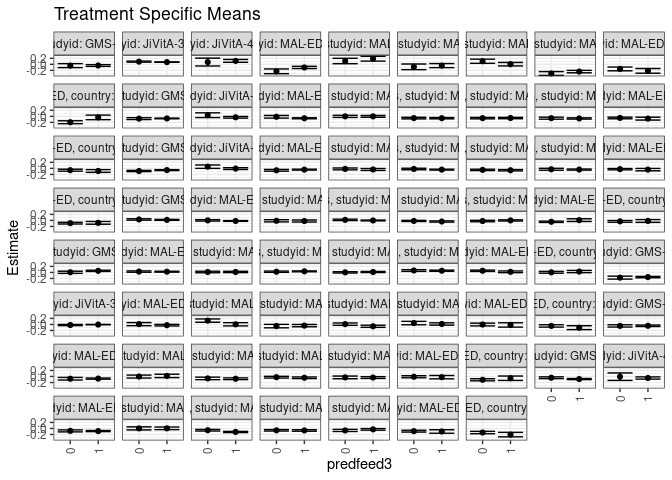

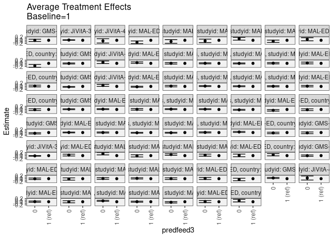

[figure not shown]

## Results Table

### Parameter: TSM

| agecat | studyid | country | intervention_level | baseline_level | estimate | ci_lower | ci_upper |
| --- | --- | --- | --- | --- | --- | --- | --- |
| 0-3 months | GMS-Nepal | NEPAL | 1 | NA | -0.0382441 | -0.0672603 | -0.0092279 |
| 0-3 months | GMS-Nepal | NEPAL | 0 | NA | -0.0422248 | -0.1079290 | 0.0234793 |
| 0-3 months | JiVitA-3 | BANGLADESH | 1 | NA | 0.0732631 | 0.0668114 | 0.0797148 |
| 0-3 months | JiVitA-3 | BANGLADESH | 0 | NA | 0.0896861 | 0.0721611 | 0.1072110 |
| 0-3 months | JiVitA-4 | BANGLADESH | 1 | NA | 0.1141399 | 0.0668478 | 0.1614319 |
| 0-3 months | JiVitA-4 | BANGLADESH | 0 | NA | 0.0755900 | -0.0543405 | 0.2055205 |
| 0-3 months | MAL-ED | BANGLADESH | 1 | NA | -0.1034583 | -0.1407715 | -0.0661451 |
| 0-3 months | MAL-ED | BANGLADESH | 0 | NA | -0.2314857 | -0.3092073 | -0.1537641 |
| 0-3 months | MAL-ED | BRAZIL | 1 | NA | 0.1871340 | 0.1064969 | 0.2677711 |
| 0-3 months | MAL-ED | BRAZIL | 0 | NA | 0.1110327 | 0.0223857 | 0.1996796 |
| 0-3 months | MAL-ED | INDIA | 1 | NA | -0.0420605 | -0.1093913 | 0.0252703 |
| 0-3 months | MAL-ED | INDIA | 0 | NA | -0.0822840 | -0.1756977 | 0.0111297 |
| 0-3 months | MAL-ED | NEPAL | 1 | NA | 0.0046456 | -0.0524836 | 0.0617748 |
| 0-3 months | MAL-ED | NEPAL | 0 | NA | 0.1031700 | 0.0347665 | 0.1715735 |
| 0-3 months | MAL-ED | PERU | 1 | NA | -0.2405936 | -0.2809755 | -0.2002117 |
| 0-3 months | MAL-ED | PERU | 0 | NA | -0.3033808 | -0.3659252 | -0.2408365 |
| 0-3 months | MAL-ED | SOUTH AFRICA | 1 | NA | -0.2165711 | -0.2938990 | -0.1392431 |
| 0-3 months | MAL-ED | SOUTH AFRICA | 0 | NA | -0.1516254 | -0.2141712 | -0.0890795 |
| 0-3 months | MAL-ED | TANZANIA, UNITED REPUBLIC OF | 1 | NA | -0.0339702 | -0.1099379 | 0.0419974 |
| 0-3 months | MAL-ED | TANZANIA, UNITED REPUBLIC OF | 0 | NA | -0.1945800 | -0.2428667 | -0.1462934 |
| 3-6 months | GMS-Nepal | NEPAL | 1 | NA | -0.1549462 | -0.1763734 | -0.1335190 |
| 3-6 months | GMS-Nepal | NEPAL | 0 | NA | -0.1736086 | -0.2224229 | -0.1247944 |
| 3-6 months | JiVitA-3 | BANGLADESH | 1 | NA | -0.0036756 | -0.0102445 | 0.0028933 |
| 3-6 months | JiVitA-3 | BANGLADESH | 0 | NA | -0.0195727 | -0.0395169 | 0.0003715 |
| 3-6 months | MAL-ED | BANGLADESH | 1 | NA | -0.0248034 | -0.0510502 | 0.0014434 |
| 3-6 months | MAL-ED | BANGLADESH | 0 | NA | 0.0093743 | -0.0417290 | 0.0604776 |
| 3-6 months | MAL-ED | BRAZIL | 1 | NA | 0.0040664 | -0.0488691 | 0.0570020 |
| 3-6 months | MAL-ED | BRAZIL | 0 | NA | 0.1261010 | 0.0715837 | 0.1806183 |
| 3-6 months | MAL-ED | INDIA | 1 | NA | -0.0388541 | -0.0766477 | -0.0010604 |
| 3-6 months | MAL-ED | INDIA | 0 | NA | -0.0545824 | -0.1120658 | 0.0029010 |

[output cut: 110 more lines]

### Parameter: E(Y)

| agecat | studyid | country | intervention_level | baseline_level | estimate | ci_lower | ci_upper |
| --- | --- | --- | --- | --- | --- | --- | --- |
| 0-3 months | GMS-Nepal | NEPAL | NA | NA | -0.0389250 | -0.0654744 | -0.0123756 |
| 0-3 months | JiVitA-3 | BANGLADESH | NA | NA | 0.0748525 | 0.0686630 | 0.0810419 |
| 0-3 months | JiVitA-4 | BANGLADESH | NA | NA | 0.1109539 | 0.0661941 | 0.1557138 |
| 0-3 months | MAL-ED | BANGLADESH | NA | NA | -0.1272271 | -0.1614593 | -0.0929949 |
| 0-3 months | MAL-ED | BRAZIL | NA | NA | 0.1488245 | 0.0885499 | 0.2090991 |
| 0-3 months | MAL-ED | INDIA | NA | NA | -0.0545690 | -0.1093806 | 0.0002426 |
| 0-3 months | MAL-ED | NEPAL | NA | NA | 0.0510100 | 0.0061541 | 0.0958660 |
| 0-3 months | MAL-ED | PERU | NA | NA | -0.2631203 | -0.2975785 | -0.2286621 |
| 0-3 months | MAL-ED | SOUTH AFRICA | NA | NA | -0.1701813 | -0.2201854 | -0.1201772 |
| 0-3 months | MAL-ED | TANZANIA, UNITED REPUBLIC OF | NA | NA | -0.1481092 | -0.1901169 | -0.1061015 |
| 3-6 months | GMS-Nepal | NEPAL | NA | NA | -0.1580566 | -0.1776900 | -0.1384232 |
| 3-6 months | JiVitA-3 | BANGLADESH | NA | NA | -0.0050744 | -0.0113651 | 0.0012163 |
| 3-6 months | MAL-ED | BANGLADESH | NA | NA | -0.0185754 | -0.0420362 | 0.0048853 |
| 3-6 months | MAL-ED | BRAZIL | NA | NA | 0.0650837 | 0.0260851 | 0.1040822 |
| 3-6 months | MAL-ED | INDIA | NA | NA | -0.0434351 | -0.0750382 | -0.0118321 |
| 3-6 months | MAL-ED | NEPAL | NA | NA | -0.0255014 | -0.0523456 | 0.0013427 |
| 3-6 months | MAL-ED | PERU | NA | NA | 0.0252665 | -0.0061992 | 0.0567322 |
| 3-6 months | MAL-ED | SOUTH AFRICA | NA | NA | -0.0065980 | -0.0455003 | 0.0323043 |
| 3-6 months | MAL-ED | TANZANIA, UNITED REPUBLIC OF | NA | NA | -0.0668448 | -0.1004432 | -0.0332465 |
| 6-9 months | GMS-Nepal | NEPAL | NA | NA | -0.0454089 | -0.0661443 | -0.0246735 |
| 6-9 months | MAL-ED | BANGLADESH | NA | NA | -0.0719928 | -0.0896446 | -0.0543410 |
| 6-9 months | MAL-ED | BRAZIL | NA | NA | 0.0070906 | -0.0301925 | 0.0443736 |
| 6-9 months | MAL-ED | INDIA | NA | NA | -0.0730513 | -0.0967576 | -0.0493449 |
| 6-9 months | MAL-ED | NEPAL | NA | NA | -0.0334124 | -0.0530149 | -0.0138099 |
| 6-9 months | MAL-ED | PERU | NA | NA | -0.0344967 | -0.0587887 | -0.0102046 |
| 6-9 months | MAL-ED | SOUTH AFRICA | NA | NA | -0.0137350 | -0.0427808 | 0.0153108 |
| 6-9 months | MAL-ED | TANZANIA, UNITED REPUBLIC OF | NA | NA | -0.0947719 | -0.1279445 | -0.0615994 |
| 9-12 months | GMS-Nepal | NEPAL | NA | NA | -0.0793581 | -0.0958225 | -0.0628937 |
| 9-12 months | JiVitA-4 | BANGLADESH | NA | NA | -0.0463035 | -0.0812128 | -0.0113943 |
| 9-12 months | MAL-ED | BANGLADESH | NA | NA | -0.0853635 | -0.1017180 | -0.0690090 |
| 9-12 months | MAL-ED | BRAZIL | NA | NA | 0.0033209 | -0.0300480 | 0.0366898 |
| 9-12 months | MAL-ED | INDIA | NA | NA | -0.0973168 | -0.1135502 | -0.0810834 |
| 9-12 months | MAL-ED | NEPAL | NA | NA | -0.0634351 | -0.0807824 | -0.0460878 |
| 9-12 months | MAL-ED | PERU | NA | NA | -0.0414622 | -0.0630765 | -0.0198479 |
| 9-12 months | MAL-ED | SOUTH AFRICA | NA | NA | -0.0920764 | -0.1191029 | -0.0650499 |
| 9-12 months | MAL-ED | TANZANIA, UNITED REPUBLIC OF | NA | NA | -0.1543757 | -0.1899833 | -0.1187681 |
| 12-15 months | GMS-Nepal | NEPAL | NA | NA | -0.0698643 | -0.0805537 | -0.0591748 |
| 12-15 months | JiVitA-4 | BANGLADESH | NA | NA | -0.0245445 | -0.0504325 | 0.0013435 |
| 12-15 months | MAL-ED | BANGLADESH | NA | NA | -0.0541395 | -0.0699573 | -0.0383217 |
| 12-15 months | MAL-ED | BRAZIL | NA | NA | -0.0004235 | -0.0234370 | 0.0225900 |
| 12-15 months | MAL-ED | INDIA | NA | NA | -0.0593506 | -0.0758306 | -0.0428707 |
| 12-15 months | MAL-ED | NEPAL | NA | NA | -0.0574001 | -0.0732076 | -0.0415925 |
| 12-15 months | MAL-ED | PERU | NA | NA | -0.0661802 | -0.0840222 | -0.0483383 |
| 12-15 months | MAL-ED | SOUTH AFRICA | NA | NA | -0.0589478 | -0.0825397 | -0.0353559 |
| 12-15 months | MAL-ED | TANZANIA, UNITED REPUBLIC OF | NA | NA | -0.0678133 | -0.0945748 | -0.0410518 |
| 15-18 months | GMS-Nepal | NEPAL | NA | NA | -0.0623706 | -0.0756949 | -0.0490463 |
| 15-18 months | JiVitA-4 | BANGLADESH | NA | NA | 0.0002451 | -0.0264873 | 0.0269774 |
| 15-18 months | MAL-ED | BANGLADESH | NA | NA | -0.0458018 | -0.0595013 | -0.0321023 |
| 15-18 months | MAL-ED | BRAZIL | NA | NA | -0.0272762 | -0.0493683 | -0.0051840 |
| 15-18 months | MAL-ED | INDIA | NA | NA | -0.0347219 | -0.0482094 | -0.0212344 |
| 15-18 months | MAL-ED | NEPAL | NA | NA | -0.0558396 | -0.0714014 | -0.0402779 |
| 15-18 months | MAL-ED | PERU | NA | NA | -0.0366273 | -0.0521417 | -0.0211130 |
| 15-18 months | MAL-ED | SOUTH AFRICA | NA | NA | -0.0303264 | -0.0494996 | -0.0111532 |
| 15-18 months | MAL-ED | TANZANIA, UNITED REPUBLIC OF | NA | NA | -0.0885708 | -0.1125745 | -0.0645671 |
| 18-21 months | GMS-Nepal | NEPAL | NA | NA | 0.0192890 | 0.0050754 | 0.0335026 |
| 18-21 months | MAL-ED | BANGLADESH | NA | NA | -0.0156920 | -0.0275555 | -0.0038285 |
| 18-21 months | MAL-ED | BRAZIL | NA | NA | -0.0173059 | -0.0423234 | 0.0077117 |
| 18-21 months | MAL-ED | INDIA | NA | NA | 0.0035076 | -0.0086867 | 0.0157020 |
| 18-21 months | MAL-ED | NEPAL | NA | NA | -0.0277114 | -0.0411503 | -0.0142726 |
| 18-21 months | MAL-ED | PERU | NA | NA | -0.0075674 | -0.0228614 | 0.0077265 |
| 18-21 months | MAL-ED | SOUTH AFRICA | NA | NA | -0.0319118 | -0.0515078 | -0.0123157 |
| 18-21 months | MAL-ED | TANZANIA, UNITED REPUBLIC OF | NA | NA | -0.0280548 | -0.0527783 | -0.0033314 |
| 21-24 months | GMS-Nepal | NEPAL | NA | NA | 0.0458107 | 0.0279350 | 0.0636865 |
| 21-24 months | MAL-ED | BANGLADESH | NA | NA | 0.0244279 | 0.0120979 | 0.0367579 |
| 21-24 months | MAL-ED | BRAZIL | NA | NA | 0.0141891 | -0.0024092 | 0.0307875 |
| 21-24 months | MAL-ED | INDIA | NA | NA | 0.0316867 | 0.0200407 | 0.0433327 |
| 21-24 months | MAL-ED | NEPAL | NA | NA | 0.0073452 | -0.0067007 | 0.0213911 |
| 21-24 months | MAL-ED | PERU | NA | NA | 0.0575837 | 0.0421321 | 0.0730353 |
| 21-24 months | MAL-ED | SOUTH AFRICA | NA | NA | 0.0454561 | 0.0281790 | 0.0627333 |
| 21-24 months | MAL-ED | TANZANIA, UNITED REPUBLIC OF | NA | NA | 0.0106677 | -0.0132987 | 0.0346340 |

### Parameter: ATE

| agecat | studyid | country | intervention_level | baseline_level | estimate | ci_lower | ci_upper |
| --- | --- | --- | --- | --- | --- | --- | --- |
| 0-3 months | GMS-Nepal | NEPAL | 1 | 1 | 0.0000000 | 0.0000000 | 0.0000000 |
| 0-3 months | GMS-Nepal | NEPAL | 0 | 1 | -0.0039808 | -0.0758067 | 0.0678452 |
| 0-3 months | JiVitA-3 | BANGLADESH | 1 | 1 | 0.0000000 | 0.0000000 | 0.0000000 |
| 0-3 months | JiVitA-3 | BANGLADESH | 0 | 1 | 0.0164230 | -0.0018211 | 0.0346670 |
| 0-3 months | JiVitA-4 | BANGLADESH | 1 | 1 | 0.0000000 | 0.0000000 | 0.0000000 |
| 0-3 months | JiVitA-4 | BANGLADESH | 0 | 1 | -0.0385499 | -0.1763734 | 0.0992736 |
| 0-3 months | MAL-ED | BANGLADESH | 1 | 1 | 0.0000000 | 0.0000000 | 0.0000000 |
| 0-3 months | MAL-ED | BANGLADESH | 0 | 1 | -0.1280274 | -0.2142418 | -0.0418130 |
| 0-3 months | MAL-ED | BRAZIL | 1 | 1 | 0.0000000 | 0.0000000 | 0.0000000 |
| 0-3 months | MAL-ED | BRAZIL | 0 | 1 | -0.0761013 | -0.1959371 | 0.0437345 |
| 0-3 months | MAL-ED | INDIA | 1 | 1 | 0.0000000 | 0.0000000 | 0.0000000 |
| 0-3 months | MAL-ED | INDIA | 0 | 1 | -0.0402235 | -0.1553736 | 0.0749267 |
| 0-3 months | MAL-ED | NEPAL | 1 | 1 | 0.0000000 | 0.0000000 | 0.0000000 |
| 0-3 months | MAL-ED | NEPAL | 0 | 1 | 0.0985244 | 0.0094021 | 0.1876466 |
| 0-3 months | MAL-ED | PERU | 1 | 1 | 0.0000000 | 0.0000000 | 0.0000000 |
| 0-3 months | MAL-ED | PERU | 0 | 1 | -0.0627872 | -0.1372352 | 0.0116607 |
| 0-3 months | MAL-ED | SOUTH AFRICA | 1 | 1 | 0.0000000 | 0.0000000 | 0.0000000 |
| 0-3 months | MAL-ED | SOUTH AFRICA | 0 | 1 | 0.0649457 | -0.0345108 | 0.1644022 |
| 0-3 months | MAL-ED | TANZANIA, UNITED REPUBLIC OF | 1 | 1 | 0.0000000 | 0.0000000 | 0.0000000 |
| 0-3 months | MAL-ED | TANZANIA, UNITED REPUBLIC OF | 0 | 1 | -0.1606098 | -0.2506247 | -0.0705949 |
| 3-6 months | GMS-Nepal | NEPAL | 1 | 1 | 0.0000000 | 0.0000000 | 0.0000000 |
| 3-6 months | GMS-Nepal | NEPAL | 0 | 1 | -0.0186624 | -0.0719724 | 0.0346476 |
| 3-6 months | JiVitA-3 | BANGLADESH | 1 | 1 | 0.0000000 | 0.0000000 | 0.0000000 |
| 3-6 months | JiVitA-3 | BANGLADESH | 0 | 1 | -0.0158971 | -0.0366889 | 0.0048947 |
| 3-6 months | MAL-ED | BANGLADESH | 1 | 1 | 0.0000000 | 0.0000000 | 0.0000000 |
| 3-6 months | MAL-ED | BANGLADESH | 0 | 1 | 0.0341777 | -0.0232718 | 0.0916272 |
| 3-6 months | MAL-ED | BRAZIL | 1 | 1 | 0.0000000 | 0.0000000 | 0.0000000 |
| 3-6 months | MAL-ED | BRAZIL | 0 | 1 | 0.1220346 | 0.0460457 | 0.1980235 |
| 3-6 months | MAL-ED | INDIA | 1 | 1 | 0.0000000 | 0.0000000 | 0.0000000 |
| 3-6 months | MAL-ED | INDIA | 0 | 1 | -0.0157283 | -0.0845230 | 0.0530663 |

[output cut: 110 more lines]

### Parameter: PAR

| agecat | studyid | country | intervention_level | baseline_level | estimate | ci_lower | ci_upper |
| --- | --- | --- | --- | --- | --- | --- | --- |
| 0-3 months | GMS-Nepal | NEPAL | 1 | NA | -0.0006809 | -0.0129677 | 0.0116059 |
| 0-3 months | JiVitA-3 | BANGLADESH | 1 | NA | 0.0015894 | -0.0001781 | 0.0033568 |
| 0-3 months | JiVitA-4 | BANGLADESH | 1 | NA | -0.0031859 | -0.0143600 | 0.0079881 |
| 0-3 months | MAL-ED | BANGLADESH | 1 | NA | -0.0237688 | -0.0409889 | -0.0065487 |
| 0-3 months | MAL-ED | BRAZIL | 1 | NA | -0.0383095 | -0.0989499 | 0.0223309 |
| 0-3 months | MAL-ED | INDIA | 1 | NA | -0.0125085 | -0.0484313 | 0.0234143 |
| 0-3 months | MAL-ED | NEPAL | 1 | NA | 0.0463644 | 0.0037021 | 0.0890267 |
| 0-3 months | MAL-ED | PERU | 1 | NA | -0.0225267 | -0.0494858 | 0.0044323 |
| 0-3 months | MAL-ED | SOUTH AFRICA | 1 | NA | 0.0463898 | -0.0247657 | 0.1175453 |
| 0-3 months | MAL-ED | TANZANIA, UNITED REPUBLIC OF | 1 | NA | -0.1141389 | -0.1789164 | -0.0493615 |
| 3-6 months | GMS-Nepal | NEPAL | 1 | NA | -0.0031104 | -0.0120203 | 0.0057995 |
| 3-6 months | JiVitA-3 | BANGLADESH | 1 | NA | -0.0013988 | -0.0032230 | 0.0004254 |
| 3-6 months | MAL-ED | BANGLADESH | 1 | NA | 0.0062279 | -0.0043823 | 0.0168381 |
| 3-6 months | MAL-ED | BRAZIL | 1 | NA | 0.0610173 | 0.0220187 | 0.1000158 |
| 3-6 months | MAL-ED | INDIA | 1 | NA | -0.0045811 | -0.0246422 | 0.0154801 |
| 3-6 months | MAL-ED | NEPAL | 1 | NA | 0.0357416 | 0.0086969 | 0.0627863 |
| 3-6 months | MAL-ED | PERU | 1 | NA | 0.0103393 | -0.0127453 | 0.0334238 |
| 3-6 months | MAL-ED | SOUTH AFRICA | 1 | NA | 0.0103551 | -0.0520662 | 0.0727764 |
| 3-6 months | MAL-ED | TANZANIA, UNITED REPUBLIC OF | 1 | NA | 0.0403030 | -0.0120847 | 0.0926907 |
| 6-9 months | GMS-Nepal | NEPAL | 1 | NA | -0.0005796 | -0.0081496 | 0.0069903 |
| 6-9 months | MAL-ED | BANGLADESH | 1 | NA | -0.0008224 | -0.0095304 | 0.0078855 |
| 6-9 months | MAL-ED | BRAZIL | 1 | NA | -0.0105540 | -0.0471255 | 0.0260176 |
| 6-9 months | MAL-ED | INDIA | 1 | NA | 0.0032328 | -0.0122700 | 0.0187356 |
| 6-9 months | MAL-ED | NEPAL | 1 | NA | 0.0098090 | -0.0099566 | 0.0295746 |
| 6-9 months | MAL-ED | PERU | 1 | NA | 0.0016263 | -0.0162119 | 0.0194645 |
| 6-9 months | MAL-ED | SOUTH AFRICA | 1 | NA | 0.0100268 | -0.0368668 | 0.0569203 |
| 6-9 months | MAL-ED | TANZANIA, UNITED REPUBLIC OF | 1 | NA | -0.0358739 | -0.0919596 | 0.0202118 |
| 9-12 months | GMS-Nepal | NEPAL | 1 | NA | 0.0074122 | 0.0014197 | 0.0134046 |
| 9-12 months | JiVitA-4 | BANGLADESH | 1 | NA | 0.0044956 | -0.0078317 | 0.0168229 |
| 9-12 months | MAL-ED | BANGLADESH | 1 | NA | 0.0011963 | -0.0056053 | 0.0079978 |
| 9-12 months | MAL-ED | BRAZIL | 1 | NA | -0.0008396 | -0.0337241 | 0.0320449 |
| 9-12 months | MAL-ED | INDIA | 1 | NA | 0.0176316 | 0.0068207 | 0.0284425 |
| 9-12 months | MAL-ED | NEPAL | 1 | NA | 0.0020648 | -0.0155289 | 0.0196586 |
| 9-12 months | MAL-ED | PERU | 1 | NA | -0.0118727 | -0.0268982 | 0.0031528 |
| 9-12 months | MAL-ED | SOUTH AFRICA | 1 | NA | 0.0078346 | -0.0390657 | 0.0547350 |
| 9-12 months | MAL-ED | TANZANIA, UNITED REPUBLIC OF | 1 | NA | 0.0492472 | -0.0104971 | 0.1089915 |
| 12-15 months | GMS-Nepal | NEPAL | 1 | NA | -0.0010392 | -0.0061400 | 0.0040617 |
| 12-15 months | JiVitA-4 | BANGLADESH | 1 | NA | 0.0063087 | -0.0021583 | 0.0147757 |
| 12-15 months | MAL-ED | BANGLADESH | 1 | NA | 0.0089222 | -0.0000883 | 0.0179327 |
| 12-15 months | MAL-ED | BRAZIL | 1 | NA | 0.0003511 | -0.0218231 | 0.0225252 |
| 12-15 months | MAL-ED | INDIA | 1 | NA | 0.0010249 | -0.0093146 | 0.0113644 |
| 12-15 months | MAL-ED | NEPAL | 1 | NA | -0.0018788 | -0.0178248 | 0.0140672 |
| 12-15 months | MAL-ED | PERU | 1 | NA | 0.0029865 | -0.0102249 | 0.0161979 |
| 12-15 months | MAL-ED | SOUTH AFRICA | 1 | NA | 0.0163911 | -0.0232887 | 0.0560708 |
| 12-15 months | MAL-ED | TANZANIA, UNITED REPUBLIC OF | 1 | NA | 0.0187014 | -0.0205718 | 0.0579746 |
| 15-18 months | GMS-Nepal | NEPAL | 1 | NA | -0.0048319 | -0.0090319 | -0.0006320 |
| 15-18 months | JiVitA-4 | BANGLADESH | 1 | NA | 0.0076043 | -0.0013656 | 0.0165742 |
| 15-18 months | MAL-ED | BANGLADESH | 1 | NA | -0.0039694 | -0.0100771 | 0.0021383 |
| 15-18 months | MAL-ED | BRAZIL | 1 | NA | 0.0088793 | -0.0121794 | 0.0299380 |
| 15-18 months | MAL-ED | INDIA | 1 | NA | 0.0067838 | -0.0026144 | 0.0161820 |
| 15-18 months | MAL-ED | NEPAL | 1 | NA | 0.0057437 | -0.0100383 | 0.0215257 |
| 15-18 months | MAL-ED | PERU | 1 | NA | 0.0029775 | -0.0088715 | 0.0148265 |
| 15-18 months | MAL-ED | SOUTH AFRICA | 1 | NA | 0.0106782 | -0.0217781 | 0.0431345 |
| 15-18 months | MAL-ED | TANZANIA, UNITED REPUBLIC OF | 1 | NA | -0.0071805 | -0.0448662 | 0.0305053 |
| 18-21 months | GMS-Nepal | NEPAL | 1 | NA | 0.0020981 | -0.0021623 | 0.0063586 |
| 18-21 months | MAL-ED | BANGLADESH | 1 | NA | 0.0036371 | -0.0013957 | 0.0086699 |
| 18-21 months | MAL-ED | BRAZIL | 1 | NA | 0.0033470 | -0.0204107 | 0.0271046 |
| 18-21 months | MAL-ED | INDIA | 1 | NA | 0.0066172 | -0.0018067 | 0.0150412 |
| 18-21 months | MAL-ED | NEPAL | 1 | NA | 0.0095476 | -0.0040890 | 0.0231843 |
| 18-21 months | MAL-ED | PERU | 1 | NA | -0.0070585 | -0.0173445 | 0.0032276 |
| 18-21 months | MAL-ED | SOUTH AFRICA | 1 | NA | -0.0404296 | -0.0764567 | -0.0044024 |
| 18-21 months | MAL-ED | TANZANIA, UNITED REPUBLIC OF | 1 | NA | -0.0097584 | -0.0482922 | 0.0287754 |
| 21-24 months | GMS-Nepal | NEPAL | 1 | NA | -0.0073210 | -0.0137947 | -0.0008473 |
| 21-24 months | MAL-ED | BANGLADESH | 1 | NA | 0.0008340 | -0.0039804 | 0.0056485 |
| 21-24 months | MAL-ED | BRAZIL | 1 | NA | 0.0000410 | -0.0160868 | 0.0161688 |
| 21-24 months | MAL-ED | INDIA | 1 | NA | -0.0042269 | -0.0121891 | 0.0037353 |
| 21-24 months | MAL-ED | NEPAL | 1 | NA | -0.0058475 | -0.0199476 | 0.0082526 |
| 21-24 months | MAL-ED | PERU | 1 | NA | 0.0027868 | -0.0083671 | 0.0139407 |
| 21-24 months | MAL-ED | SOUTH AFRICA | 1 | NA | 0.0264975 | 0.0002707 | 0.0527242 |
| 21-24 months | MAL-ED | TANZANIA, UNITED REPUBLIC OF | 1 | NA | -0.0175559 | -0.0508313 | 0.0157196 |